# Exploratory Data Analysis

Ana Martins

2022-10-02

## Introduction

```r
library(tidyverse)
library(magrittr)
library(mice)
library(DAAG)
```

## The `boys` data

```r
head(boys)
```

```
##      age  hgt   wgt   bmi   hc  gen  phb tv   reg
## 3  0.035 50.1 3.650 14.54 33.7 <NA> <NA> NA south
## 4  0.038 53.5 3.370 11.77 35.0 <NA> <NA> NA south
## 18 0.057 50.0 3.140 12.56 35.2 <NA> <NA> NA south
## 23 0.060 54.5 4.270 14.37 36.7 <NA> <NA> NA south
## 28 0.062 57.5 5.030 15.21 37.3 <NA> <NA> NA south
## 36 0.068 55.5 4.655 15.11 37.0 <NA> <NA> NA south
```

```r
tail(boys)
```

```
##         age   hgt  wgt   bmi   hc  gen  phb tv   reg
## 7410 20.372 188.7 59.8 16.79 55.2 <NA> <NA> NA  west
## 7418 20.429 181.1 67.2 20.48 56.6 <NA> <NA> NA north
## 7444 20.761 189.1 88.0 24.60   NA <NA> <NA> NA  west
## 7447 20.780 193.5 75.4 20.13   NA <NA> <NA> NA  west
## 7451 20.813 189.0 78.0 21.83 59.9 <NA> <NA> NA north
## 7475 21.177 181.8 76.5 23.14   NA <NA> <NA> NA  east
```

```r
!is.unsorted(boys$age)
```

```
## [1] TRUE
```

```r
summary(boys)
```

```
##       age              hgt              wgt              bmi
##  Min.   : 0.035   Min.   : 50.00   Min.   :  3.14   Min.   :11.77
##  1st Qu.: 1.581   1st Qu.: 84.88   1st Qu.: 11.70   1st Qu.:15.90
##  Median :10.505   Median :147.30   Median : 34.65   Median :17.45
##  Mean   : 9.159   Mean   :132.15   Mean   : 37.15   Mean   :18.07
##  3rd Qu.:15.267   3rd Qu.:175.22   3rd Qu.: 59.58   3rd Qu.:19.53
##  Max.   :21.177   Max.   :198.00   Max.   :117.40   Max.   :31.74
##                   NA's   :20       NA's   :4        NA's   :21
##        hc          gen        phb            tv           reg
##  Min.   :33.70   G1  : 56   P1  : 63   Min.   : 1.00   north: 81
##  1st Qu.:48.12   G2  : 50   P2  : 40   1st Qu.: 4.00   east :161
##  Median :53.00   G3  : 22   P3  : 19   Median :12.00   west :239
##  Mean   :51.51   G4  : 42   P4  : 32   Mean   :11.89   south:191
##  3rd Qu.:56.00   G5  : 75   P5  : 50   3rd Qu.:20.00   city : 73
##  Max.   :65.00   NA's:503   P6  : 41   Max.   :25.00   NA's :  3
##  NA's   :46                 NA's:503   NA's   :522
```

1. **Create a histogram of the variable `age` using the function `geom_histogram()`.**

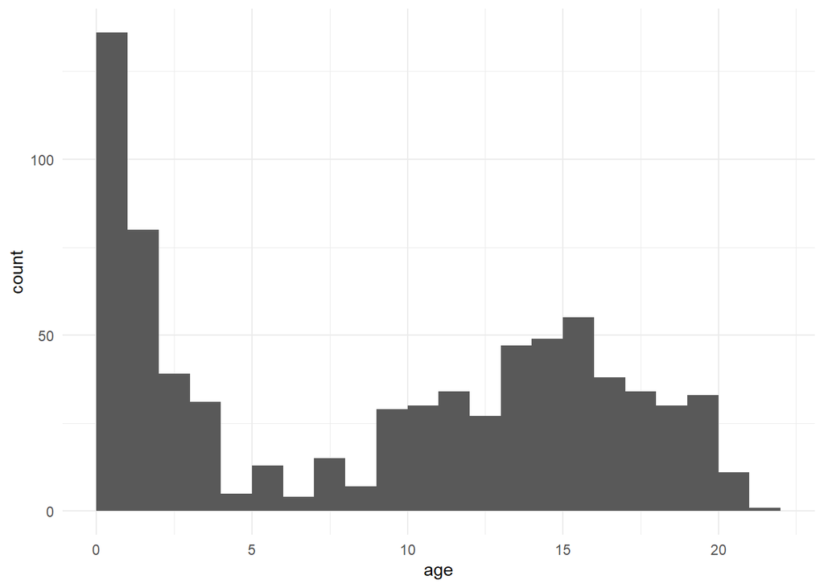

```r
boys_histo <-
  boys %>%
  ggplot(aes(x = age)) +
  geom_histogram(binwidth = 1, boundary = 0) +
  theme_minimal()

boys_histo
```

2. **Create a bar chart of the variable `gen` using the function `geom_bar()`.**

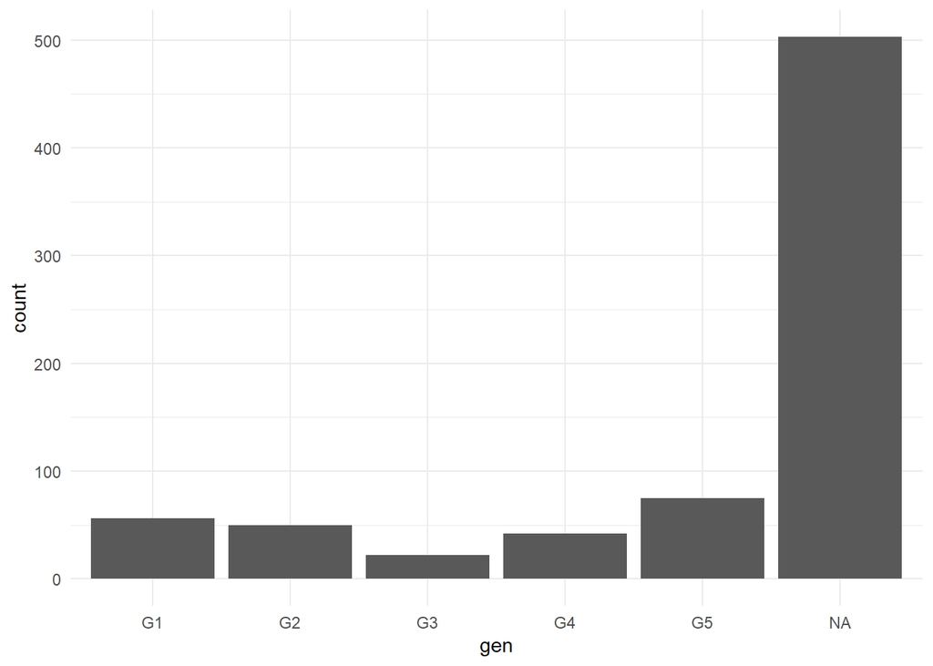

```r
boys_bar <-
  boys %>%
  ggplot(aes(x = gen)) +
  geom_bar() +
  theme_minimal()

boys_bar
```

## Assessing missing data

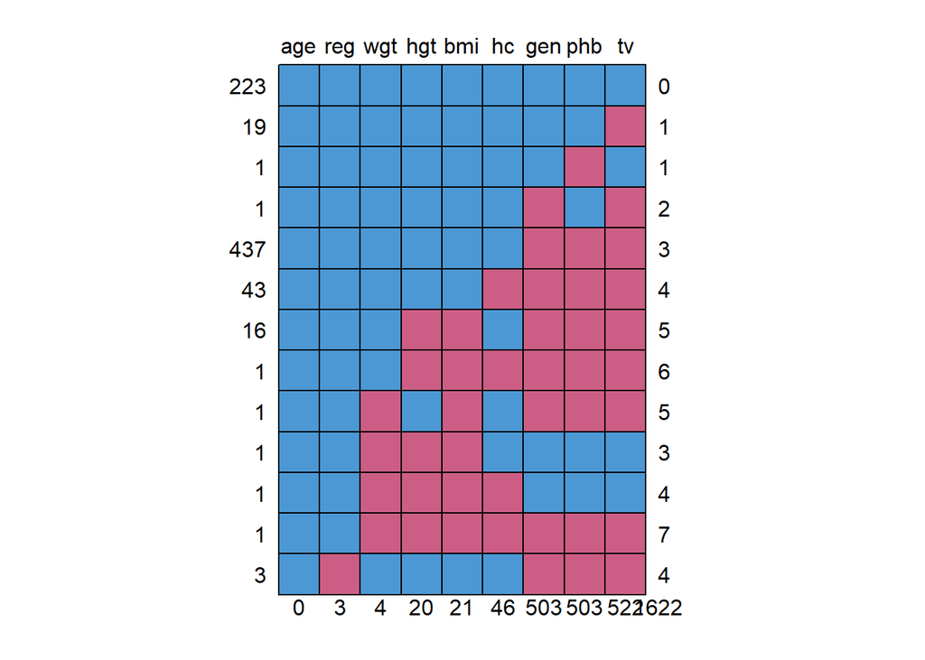

```
##     age reg wgt hgt bmi hc gen phb  tv
## 223   1   1   1   1   1  1   1   1   1    0
## 19    1   1   1   1   1  1   1   1   0    1
## 1     1   1   1   1   1  1   1   0   1    1
## 1     1   1   1   1   1  1   0   1   0    2
## 437   1   1   1   1   1  1   0   0   0    3
## 43    1   1   1   1   1  0   0   0   0    4
## 16    1   1   1   0   0  1   0   0   0    5
## 1     1   1   1   0   0  0   0   0   0    6
## 1     1   1   0   1   0  1   0   0   0    5
## 1     1   1   0   0   0  1   1   1   1    3
## 1     1   1   0   0   0  0   1   1   1    4
## 1     1   1   0   0   0  0   0   0   0    7
## 3     1   0   1   1   1  1   0   0   0    4
##       0   3   4  20  21 46 503 503 522 1622
```

```r
md.pattern(boys)
```

3. **Create a missingness indicator for the variables `gen`, `phb` and `tv.**

```r
boys_missingness <- boys %>%
  mutate(gen_missingness = is.na(gen),
         phb_missingness = is.na(phb),
         tv_missingness  = is.na(tv))
```

4. **Assess whether missingness in the variables `gen`, `phb` and `tv` is related to someones age.**

```r
boys_missingness %>%
  group_by(gen_missingness) %>%
  summarise(age = mean(age))
```

```
## # A tibble: 2 × 2
##   gen_missingness   age
##   <lgl>           <dbl>
## 1 FALSE           14.0
## 2 TRUE             6.79
```

```r
boys_missingness %>%
  group_by(phb_missingness) %>%
  summarise(age = mean(age))
```

```
## # A tibble: 2 × 2
##   phb_missingness   age
##   <lgl>           <dbl>
## 1 FALSE           14.0
## 2 TRUE             6.79
```

```r
boys_missingness %>%
  group_by(tv_missingness) %>%
  summarise(age = mean(age))
```

```
## # A tibble: 2 × 2
##   tv_missingness   age
##   <lgl>          <dbl>
## 1 FALSE          14.1
## 2 TRUE            7.02
```

5. **Create a histogram for the variable `age`, faceted by whether or not someone has a missing value on `gen`.**

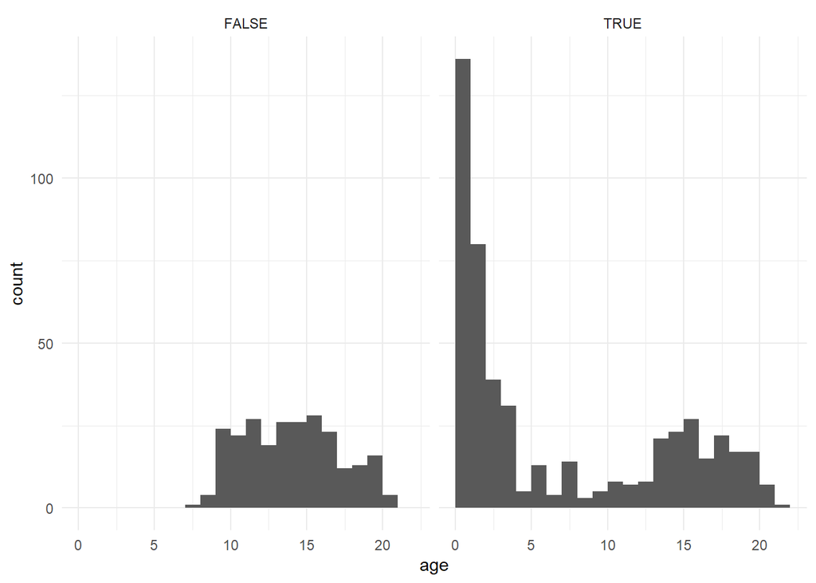

```r
boys_missingness %>%
  ggplot(aes(age)) +
  geom_histogram(binwidth = 1, boundary = 0) +
  facet_wrap(~ gen_missingness) +
  theme_minimal()
```

6. **Create a scatterplot with age on the x-axis and bmi on the y-axis, using the function geom_point().**

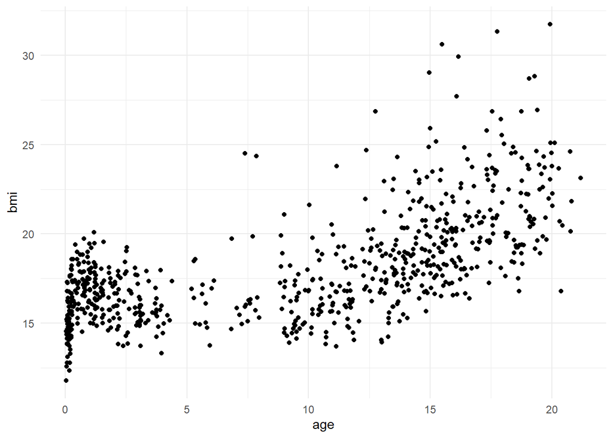

```r
boys_missingness %>%
  ggplot(aes(x = age, y = bmi)) +
  geom_point() +
  theme_minimal()
```

7. **Add a colour aesthetic to the previous plot using the missingness indicator of the variable gen.**

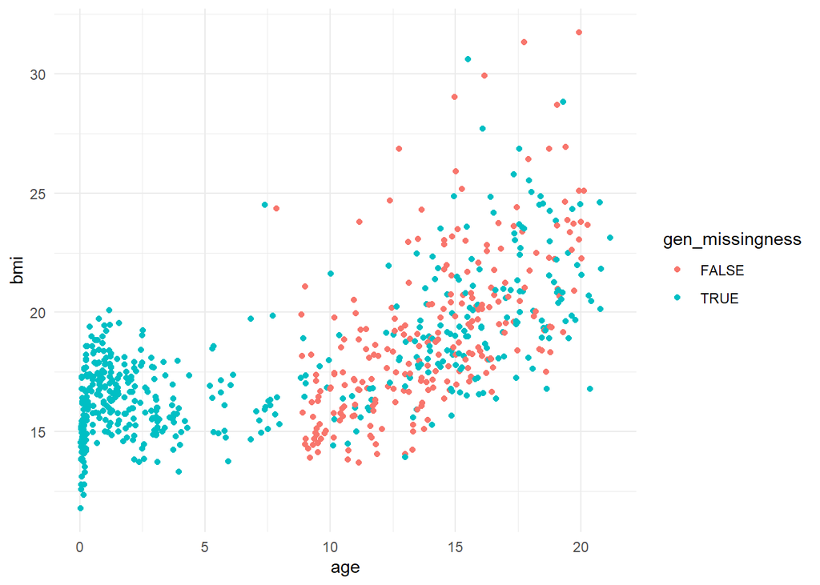

```r
boys_missingness %>%
  ggplot(aes(x = age, y = bmi, color = gen_missingness)) +
  geom_point() +
  theme_minimal()
```

## Visualizing the boys data

8. Visualize the relationship between reg (region) and age using a boxplot.

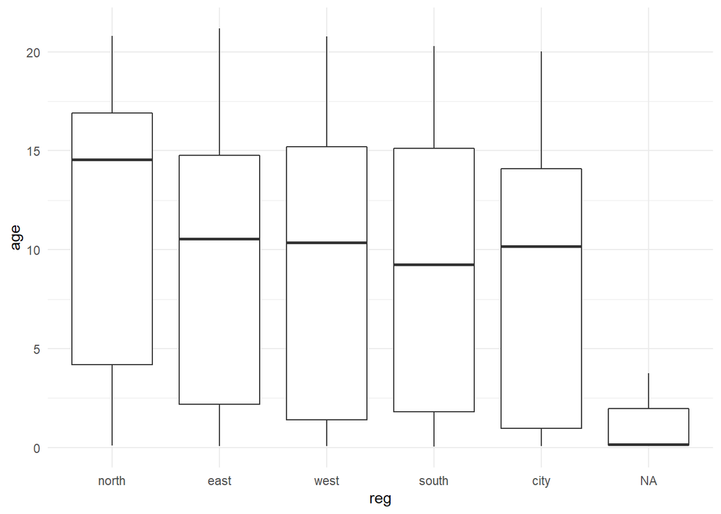

```r
boys %>%
  ggplot(aes(x = reg, y = age)) +
  geom_boxplot() +
  theme_minimal()
```

9. **Create a density plot of age, splitting the densities by gen using the fill aesthetic.**

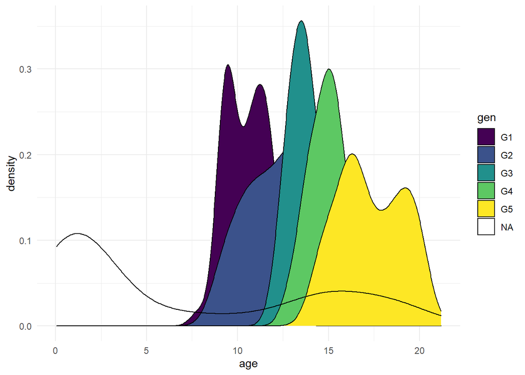

```r
boys %>%
  ggplot(aes(x = age, fill = gen)) +
  geom_density() +
  theme_minimal()
```

10. **Create a diverging bar chart for `hgt` in the `boys` data set, that displays for every `age` year that year’s mean height in deviations from the overall average `hgt`.**

[figure not shown]

```r
boys %>%
  select(age, hgt) %>%
  drop_na() %>%
  mutate(age = as.factor(age), hgt_dev = hgt - mean(hgt, na.rm = TRUE)) %>%
  group_by(age) %>%
  summarise(hgt_dev = mean(hgt_dev, na.rm = TRUE)) %>%
  ggplot(aes(hgt_dev, age)) +
  geom_bar(stat = "identity") +
  theme_minimal()
```

## Regression visualization

11. *Load the data `elastic1` and `elastic2` and bind the data frames together using the function `bind_rows()` and add a grouping variable indicating whether an observation comes from `elastic1` or from `elastic2`.*

```r
library(DAAG)

help(elastic1)
```

```
## starting httpd help server ... done
```

```r
help(elastic2)

elastics <-
  bind_rows("elastic1" = elastic1, "elastic2" = elastic2, .id = "set")
```

12. **Create a scatterplot mapping `stretch` on the x-axis and `distance` on the y-axis, and map the just created group indicator as the color aesthetic.**

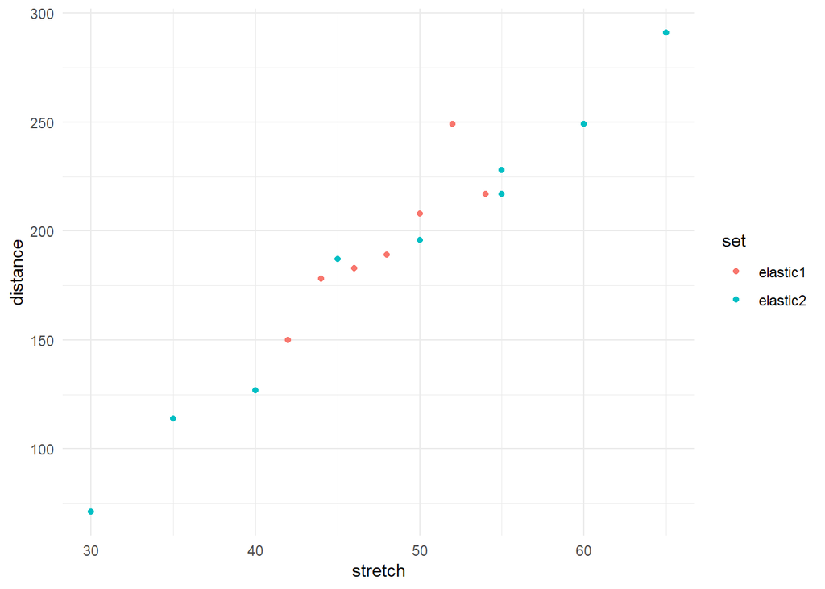

```r
elastics %>%
  ggplot(aes(x = stretch, y = distance, color = set)) +
  geom_point() +
  theme_minimal()
```

13. **Recreate the previous plot, but now assess whether the results of the two data sets appear consistent by adding a linear regression line.**

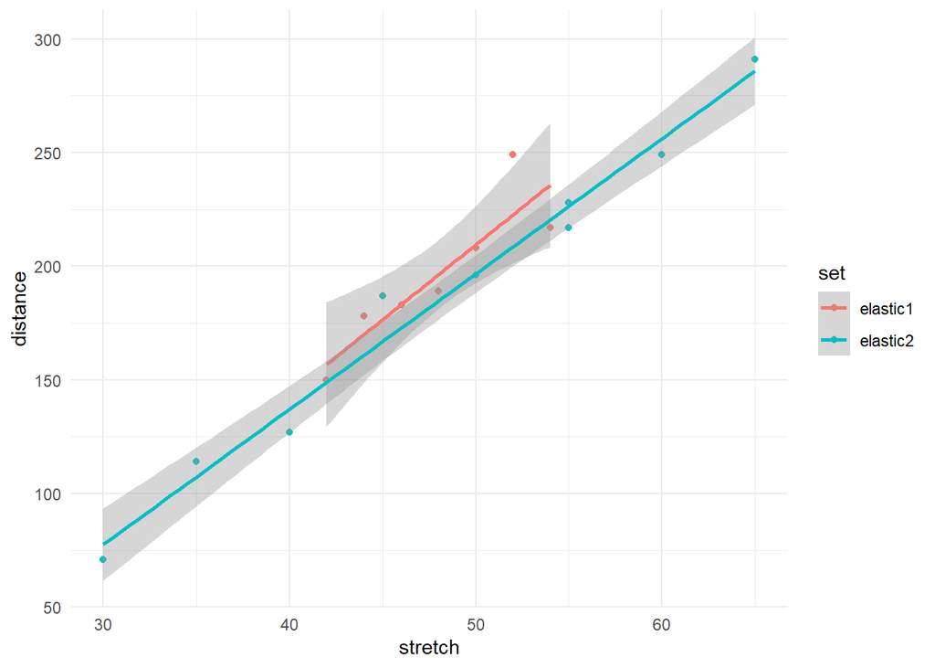

```r
elastics %>%
  ggplot(aes(x = stretch, y = distance, color = set)) +
  geom_point() +
  geom_smooth(method = "lm") +
  theme_minimal()
```

14. **For each of the data sets `elastic1` and `elastic2`, fit a regression model with `y = distance` on `x = stretch` using `lm(y ~ x, data)`.**

```r
fit1 <- lm(distance ~ stretch, elastic1)
fit2 <- lm(distance ~ stretch, elastic2)
```

15. **For both of the previously created fitted models, determine the fitted values and the standard errors of the fitted values, and the proportion explained variance R2.**

```r
fit1 %>%
  predict(se.fit = TRUE)
```

```
## $fit
##        1        2        3        4        5        6        7
## 183.1429 235.7143 196.2857 209.4286 170.0000 156.8571 222.5714
##
## $se.fit
## [1]  6.586938 10.621119  5.891537  6.586938  8.331891 10.621119  8.331891
##
## $df
## [1] 5
##
## $residual.scale
## [1] 15.58754
```

```r
fit1 %>% summary() %$% r.squared
```

```
## [1] 0.7992446
```

```r
fit2 %>%
  predict(se.fit = TRUE)
```

```
## $fit
##         1         2         3         4         5         6         7         8
##  77.58333 196.58333 137.08333 166.83333 256.08333 226.33333 107.33333 226.33333
##         9
## 285.83333
##
## $se.fit
## [1] 6.740293 3.520003 4.358744 3.635444 5.060323 4.064550 5.453165 4.064550
## [9] 6.296773
##
## $df
## [1] 7
##
## $residual.scale
## [1] 10.44202
```

```r
fit2 %>% summary() %$% r.squared
```

```
## [1] 0.9807775
```

16. **Study the residual versus leverage plots for both models.**

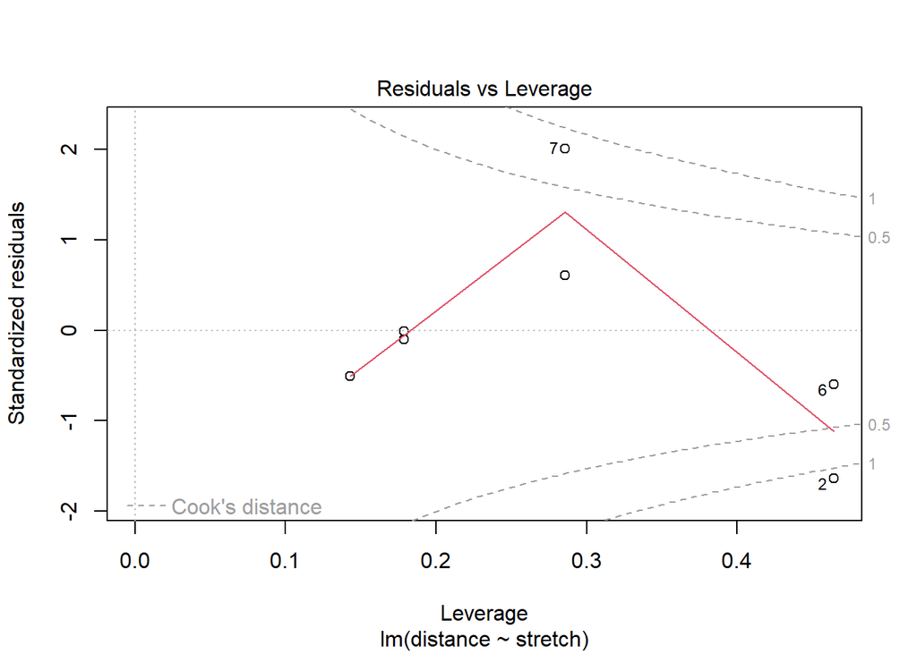

```r
fit1 %>% plot(which = 5)
```

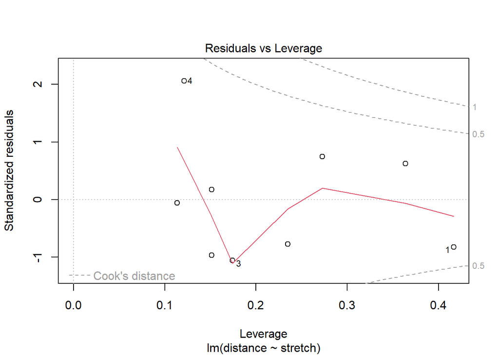

```r
fit2 %>% plot(which = 5)
```

17. **Use the `elastic2` variable stretch to obtain predictions on the model fitted on `elastic1`.*

```r
pred <- predict(fit1, newdata = elastic2)
```

18. **Now make a scatterplot to investigate similarity between the predicted values and the observed values for `elastic2`.**

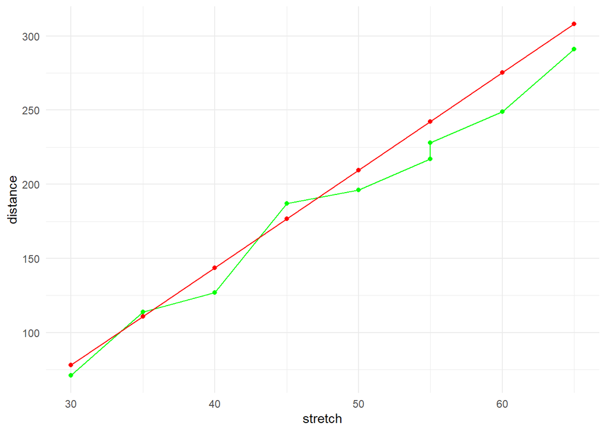

```r
pred <- data.frame(distance = pred, stretch  = elastic2$stretch)

ggplot() +
  geom_point(data = elastic2, mapping = aes(x = stretch, y = distance), color = "Green") +
  geom_line(data = elastic2, mapping = aes(x = stretch, y = distance), color = "Green") +
  geom_point(data = pred, mapping = aes(x = stretch, y = distance), color = "Red") +
  geom_line(data = pred, mapping = aes(x = stretch, y = distance), color = "Red") +
  theme_minimal()
```